# Simple EDA using dplyr and ggplot2

Author

[Michael Love](http://mikelove.github.io)

In this document, we will explore a small table of data about the genomes of various organisms. I also include a file, `scrape_ensembl.R` which shows how I scraped this data from the [Ensembl](http://ensembl.org) website.

We start by reading in the TSV (tab-separated value) data using the readr package:

```r
library(readr)
library(here)
orgs <- read_tsv(here("eda","organisms_genes.tsv"))
head(orgs)
```

```
# A tibble: 6 × 8
  type   name                species                        bp coding noncoding pseudo    tx
  <chr>  <chr>               <chr>                       <dbl>  <dbl>     <dbl>  <dbl> <dbl>
1 mammal Alpaca              Vicugna_pacos          2967746133  11765      2532    898 15236
2 fish   Amazon molly        Poecilia_formosa        748923461  23615       679     60 31637
3 invert Roundword           Caenorhabditis_elegans  100286401  20362     24719   1658 58941
4 invert Sea squirt          Ciona_intestinalis      115227500  16671       455     27 17784
5 invert Solitary sea squirt Ciona_savignyi          177003750  11616       340    216 20711
6 mammal Cat                 Felis_catus            2455541136  19493      1855    542 22656
```

```r
table(orgs$type)
```

```
  bird   fish invert mammal  plant single
     4      8      7     14      4      1
```

`read_tsv` returns a *tibble* object, which is similar to a *data.frame*, being tabular data with different types of variables as columns (character, double, integer, etc.). One difference, aside from the presentation when you `show` the object, is that the characters are not automatically converted to *factor*, as they are with `read.delim` or the like.

Let’s convert the first column to a *factor*:

```r
orgs$type <- factor(orgs$type)
```

Let’s make some plots of the number of basepairs in the genomes of these organisms, split by the type of organism. There’s one plant with a really large genome. We could use the `stripplot` function, which is in the `lattice` package: this draws points for each level of a factor, similar to a boxplot, but is preferred when there are not many observations (e.g. < 20).

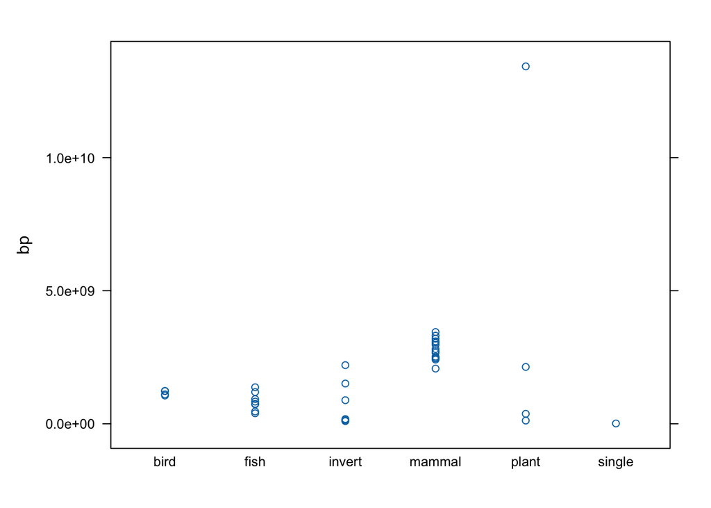

```r
library(lattice)
with(orgs, stripplot(bp ~ type))
```

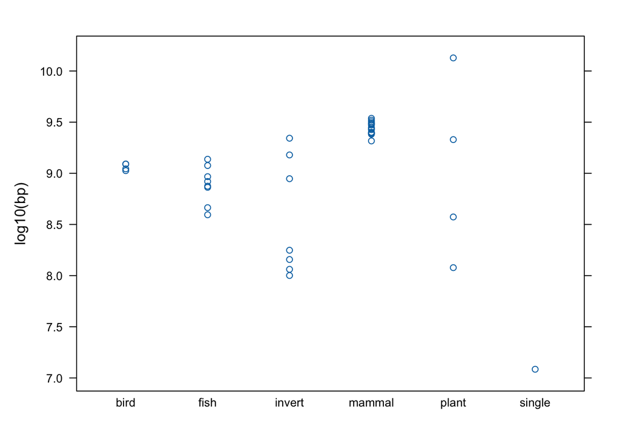

```r
with(orgs, stripplot(log10(bp) ~ type))
```

Compare to boxplot. Again, given the small number of samples, `stripplot` is preferred.

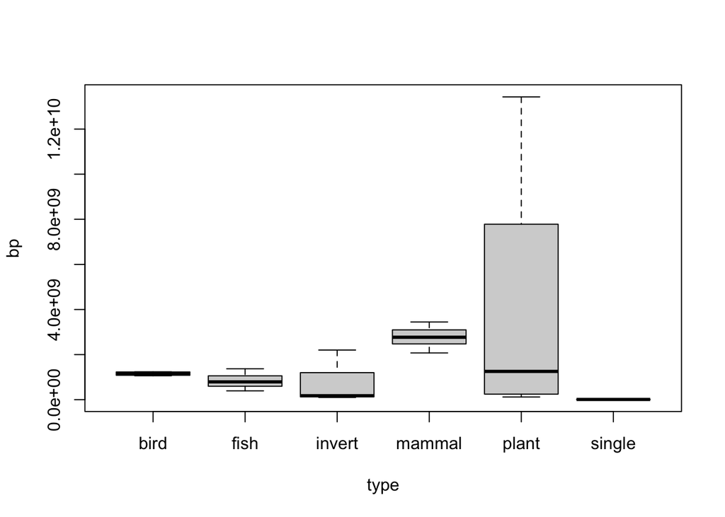

```r
with(orgs, boxplot(bp ~ type))
```

If you haven’t seen `with(...)` before, it’s a way to temporarily use the variables (columns) of a *data.frame* as if they were variables in the environment, that is, without using the `$`. As we will see below, `ggplot2` also offers such a convenient syntax for working with column names.

Most of the organisms have around 1 billion basepairs in their genome.

That large genome is wheat.

```r
orgs[which.max(orgs$bp),]
```

```
# A tibble: 1 × 8
  type  name  species                    bp coding noncoding pseudo     tx
  <fct> <chr> <chr>                   <dbl>  <dbl>     <dbl>  <dbl>  <dbl>
1 plant Wheat Triticum_aestivum 13427354022 104272     10156     NA 166589
```

Let’s remove it for now to make plots where we can see the range of the other organisms.

```r
orgs <- orgs[orgs$name != "Wheat",]
```

I plot the number of genes that code for proteins over the total number of basepairs:

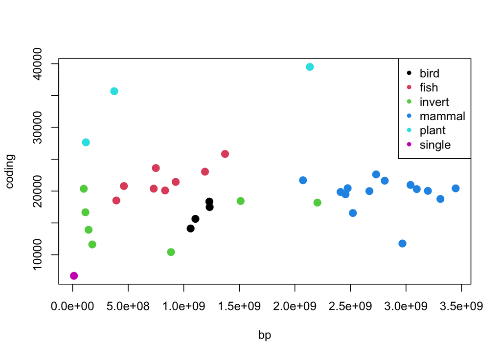

```r
with(orgs, plot(bp, coding, col=type, pch=20, cex=2))
legend("topright", levels(orgs$type), col=1:nlevels(orgs$type), pch=20)
```

```r
# right click to Esc from identify()
# with(orgs, identify(bp, coding, labels=orgs$name))
```

Another way to make a plot with labels is using [ggplot2](http://ggplot2.tidyverse.org/reference/). In ggplot2, you build a plot by adding layers with `+`: a call to `ggplot()` sets up the coordinate system and maps columns to visual properties via `aes()`, and then `geom_*` functions draw the data. Common geoms include `geom_point()`, `geom_line()`, `geom_histogram()`, `geom_density()`, `geom_boxplot()`, and `geom_smooth()`.

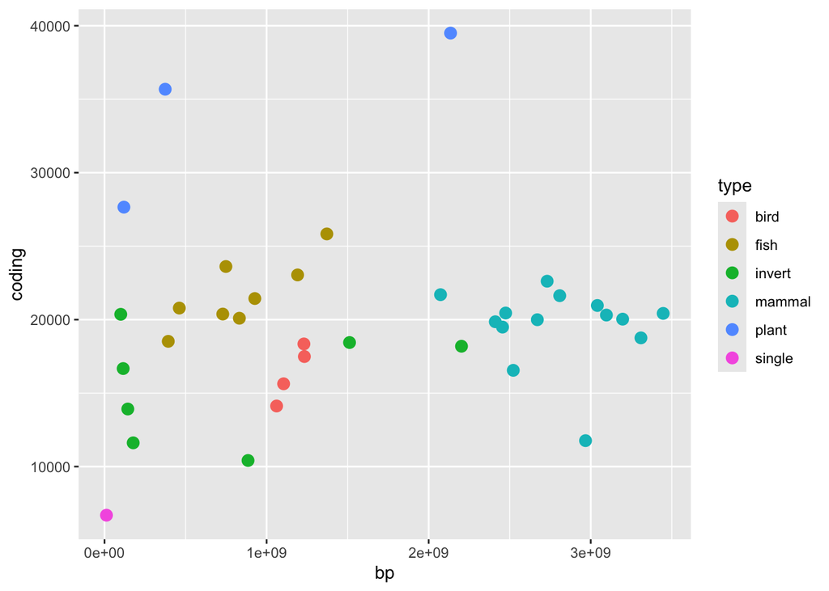

```r
library(ggplot2)
ggplot(orgs, aes(bp, coding, color=type)) +
  geom_point(size=3)
```

Which organisms have the largest genome (after wheat)?

```r
orgs[order(orgs$bp, decreasing=TRUE)[1:5],c("name","bp")]
```

```
# A tibble: 5 × 2
  name               bp
  <chr>           <dbl>
1 Orangutan  3446771396
2 Chimpanzee 3309577922
3 Elephant   3196760833
4 Human      3096649726
5 Gorilla    3040677044
```

Another way to get quick summaries of a dataset is `skim` from the *skimr* package:

```r
library(skimr)
skim(orgs)
```

Data summary

| Name | orgs |
| --- | --- |
| Number of rows | 37 |
| Number of columns | 8 |
| _______________________ |  |
| Column type frequency: |  |
| character | 2 |
| factor | 1 |
| numeric | 5 |
| ________________________ |  |
| Group variables | None |

**Variable type: character**

| skim_variable | n_missing | complete_rate | min | max | empty | n_unique | whitespace |
| --- | --- | --- | --- | --- | --- | --- | --- |
| name | 0 | 1 | 3 | 19 | 0 | 37 | 0 |
| species | 0 | 1 | 8 | 24 | 0 | 37 | 0 |

**Variable type: factor**

| skim_variable | n_missing | complete_rate | ordered | n_unique | top_counts |
| --- | --- | --- | --- | --- | --- |
| type | 0 | 1 | FALSE | 6 | mam: 14, fis: 8, inv: 7, bir: 4 |

**Variable type: numeric**

| skim_variable | n_missing | complete_rate | mean | sd | p0 | p25 | p50 | p75 | p100 | hist |
| --- | --- | --- | --- | --- | --- | --- | --- | --- | --- | --- |
| bp | 0 | 1.00 | 1.574812e+09 | 1.111087e+09 | 12157105 | 729664433.00 | 1233186341 | 2.521924e+09 | 3446771396 | ▆▇▁▆▅ |
| coding | 0 | 1.00 | 1.981016e+04 | 5.999450e+03 | 6692 | 17488.00 | 20033 | 2.143700e+04 | 39498 | ▂▅▇▁▁ |
| noncoding | 0 | 1.00 | 5.999380e+03 | 1.008250e+04 | 340 | 1042.00 | 2644 | 6.492000e+03 | 55401 | ▇▁▁▁▁ |
| pseudo | 3 | 0.92 | 1.276790e+03 | 3.056010e+03 | 21 | 69.25 | 382 | 8.727500e+02 | 14589 | ▇▁▁▁▁ |
| tx | 0 | 1.00 | 4.099754e+04 | 3.876149e+04 | 7126 | 21326.00 | 29196 | 3.811800e+04 | 199234 | ▇▁▁▁▁ |

For many operations, it’s useful to use the dplyr package to manipulate *data.frames* or *tibbles*.

Before I show dplyr operations, let me introduce the pipe operator `|>`, which sends the left-hand side to the first argument of the function on the right-hand side.

A simple example of the pipe:

```r
x <- c(1:9,1000)
x |> mean(trim=.1)
```

```
[1] 5.5
```

```r
# equivalent to
mean(x, trim=.1)
```

```
[1] 5.5
```

Using dplyr, let’s add a new column tallying up coding and non-coding genes:

```r
library(dplyr)
orgs <- orgs |> mutate(genes = coding + noncoding)
orgs$genes
```

```
 [1] 14297 24294 45081 17126 11956 21348 25250 24838 27440 21636 23819 31754 20340 16201 22677 17302
[17] 19226 27663 22591 42839 13067 36914 27420 24754 20751 29229  7105 22404 27063 14878 19231 19748
[33] 31892 18212 29053 44474 91080
```

dplyr is really useful for grouping and summarization tasks. The following line groups the organisms by type and summarizes the number for each type, the mean ratio of genes which are coding and the standard deviation of the ratio. One `type` has an SD of NA, why?

```r
orgs |>
  group_by(type) |>
  summarize(n=n(),
            cr_avg=mean(coding/genes),
            cr_sd=sd(coding/genes))
```

```
# A tibble: 6 × 4
  type       n cr_avg   cr_sd
  <fct>  <int>  <dbl>   <dbl>
1 bird       4  0.903  0.110
2 fish       8  0.911  0.0722
3 invert     7  0.840  0.187
4 mammal    14  0.764  0.128
5 plant      3  0.744  0.307
6 single     1  0.942 NA
```

Let’s save this as a new table, `tab`:

```r
tab <- orgs |>
  group_by(type) |>
  summarize(n=n(),
            cr_avg=mean(coding/genes),
            cr_sd=sd(coding/genes))
```

Two packages with functions for printing tables (as Latex or markdown):

```r
library(xtable)
xtable(tab)
```

```
% latex table generated in R 4.6.0 by xtable 1.8-8 package
% Fri Aug 21 12:25:53 2026
\begin{table}[ht]
\centering
\begin{tabular}{rlrrr}
  \hline
 & type & n & cr\_avg & cr\_sd \\
  \hline
1 & bird &   4 & 0.90 & 0.11 \\
  2 & fish &   8 & 0.91 & 0.07 \\
  3 & invert &   7 & 0.84 & 0.19 \\
  4 & mammal &  14 & 0.76 & 0.13 \\
  5 & plant &   3 & 0.74 & 0.31 \\
  6 & single &   1 & 0.94 &  \\
   \hline
\end{tabular}
\end{table}
```

```r
library(knitr)
kable(tab)
```

| type | n | cr_avg | cr_sd |
| --- | --- | --- | --- |
| bird | 4 | 0.9032821 | 0.1099685 |
| fish | 8 | 0.9111016 | 0.0721778 |
| invert | 7 | 0.8396879 | 0.1866490 |
| mammal | 14 | 0.7637233 | 0.1281888 |
| plant | 3 | 0.7439093 | 0.3066560 |
| single | 1 | 0.9418719 | NA |

We can use summarization as a mid-point and then send those summaries to a plotting function. For example, points and line ranges:

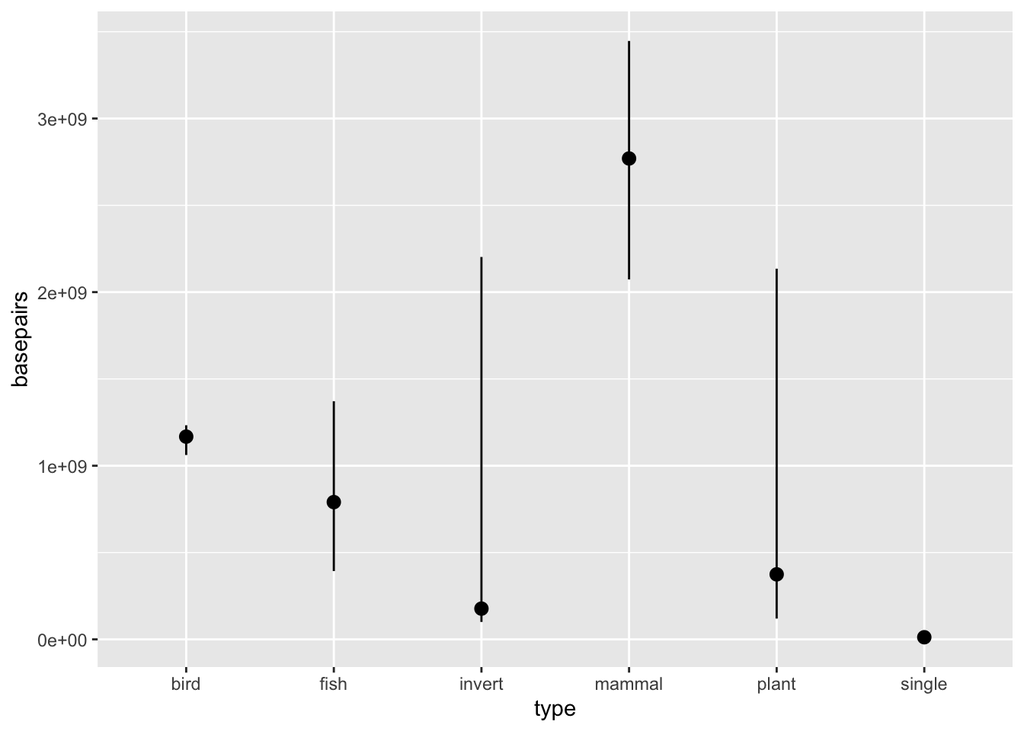

```r
# here we have to name the median something other than `bp`
orgs |>
  group_by(type) |>
  summarize(basepairs=median(bp),
            min=min(bp),
            max=max(bp)) |>
  ggplot(aes(type, basepairs, ymin=min, ymax=max)) +
  geom_pointrange()
```

ggplot2 is great for grouping points together with summarizing graphical elements, such as lines through sets of points:

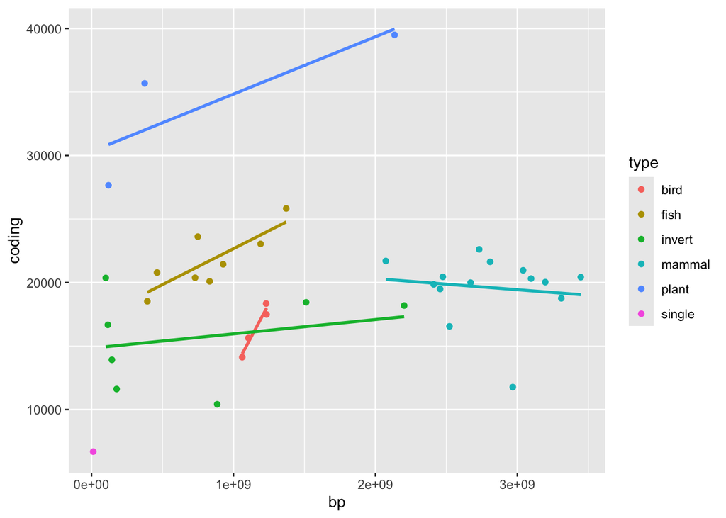

```r
ggplot(orgs, aes(bp, coding, col=type)) +
  geom_point() +
  geom_smooth(se=FALSE, method="lm", show.legend=FALSE)
```

Also for “faceting” plots, breaking into multiple scatter plots by breaking along a variable:

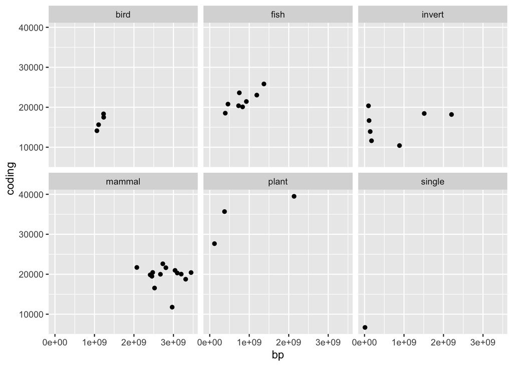

```r
ggplot(orgs, aes(bp, coding)) +
  geom_point() +
  facet_wrap(~ type)
```

Finally, I like to show a useful plot constructed using ggplot2, just with simulated data. It is common that wants to show overlapping densities or histograms, which is not a simple task with base R graphics. It’s fairly simple with ggplot2.

We create some simulated data drawing three sets of samples from three distributions.

```r
ns <- c(1000,500,200)
dat <- data.frame(type=rep(letters[1:3], ns),
                  z=rnorm(1700,
                          mean=rep(c(0,2,4),ns),
                          sd=rep(c(1,1,1),ns)))
head(dat)
```

```
  type          z
1    a  0.2433481
2    a -1.0434283
3    a -0.2626796
4    a  0.7718134
5    a -0.1029875
6    a  1.8144688
```

```r
table(dat$type)
```

```
   a    b    c
1000  500  200
```

It’s straightforward to draw these as overlapping densities:

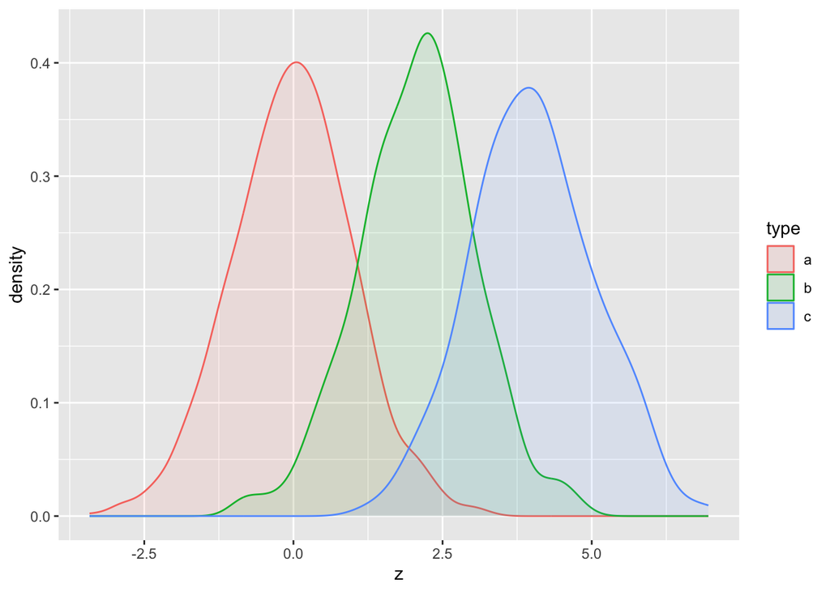

```r
ggplot(dat, aes(z, col=type, fill=type)) + geom_density(alpha=0.1)
```

Or as histograms:

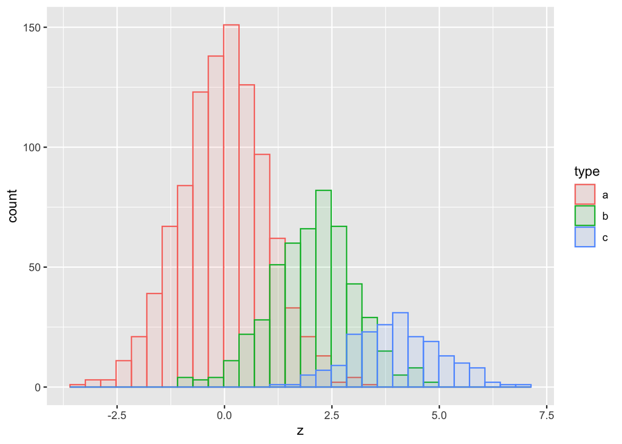

```r
ggplot(dat, aes(z, col=type, fill=type)) +
  geom_histogram(alpha=0.1, position="identity")
```

Another option, putting the bars beside each other:

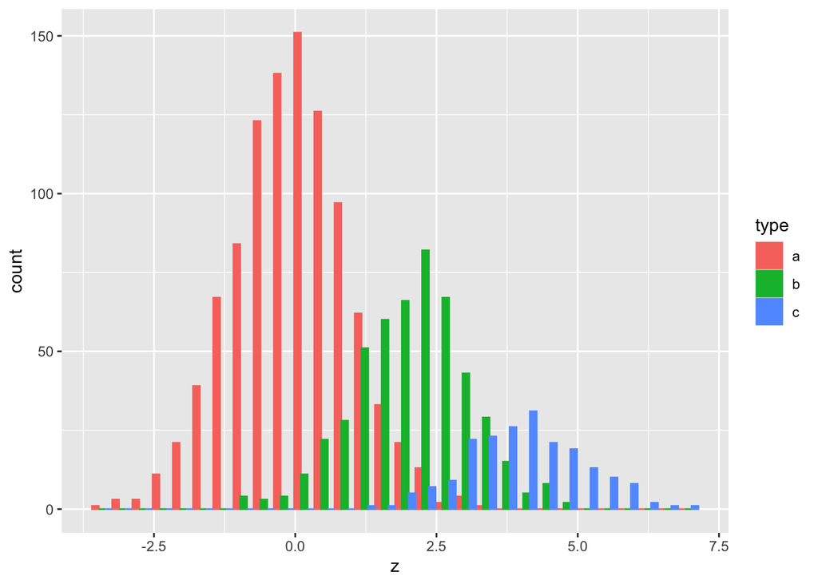

```r
ggplot(dat, aes(z, col=type, fill=type)) +
  geom_histogram(position="dodge")
```

## Appendix: `|>` vs `%>%` and the placeholder

R 4.1 introduced a native pipe `|>` that covers the most common use case: passing the left-hand side to the *first* argument of the right-hand side. For almost everything in this course, `|>` and `%>%` (from the *magrittr* package) are interchangeable.

The one place they differ is the placeholder, a way to pipe into an argument that is not the first, or that is nested inside another call.

Base R uses `_` as a placeholder, but only as a direct named argument.

```r
library(magrittr)
orgs |> lm(coding ~ bp, data = _) |> coef() # base R
```

```
 (Intercept)           bp
1.894803e+04 5.474499e-07
```

```r
orgs %>% lm(coding ~ bp, data = .) %>% coef() # magrittr equivalent
```

```
 (Intercept)           bp
1.894803e+04 5.474499e-07
```

```r
orgs %>% lm(coding ~ bp, data = .) %>% coef # magrittr can drop ()
```

```
 (Intercept)           bp
1.894803e+04 5.474499e-07
```

Magrittr’s `.` can appear anywhere on the right-hand side, including nested inside another call. Here we compute `trim` from the data itself:

```r
x <- c(1:9, 1000)
x |> mean(trim = 0.1)
```

```
[1] 5.5
```

```r
x %>% mean(trim = 1/length(.))  # trim = 1/10 = 0.1
```

```
[1] 5.5
```

```r
# x |> mean(trim = 1/length(_)) # syntax error
```

Magrittr also provides `%<>%`, a compound assignment pipe that applies a function and reassigns the result to the left-hand side. There is no base R equivalent; the plain `<-` form is always a safe replacement:

```r
# these two are equivalent
orgs$type %<>% factor       # magrittr compound assignment
orgs$type <- factor(orgs$type)  # base R
```